# Project 1 Final Report

```r
library(tidyverse)
library(httr)
library(jsonlite)
library(tidyjson)
library(glue)
library(countrycode)
library(gt)
library(hrbrthemes)
library(viridis)
library(hexbin)
```

```r
plastics <- readr::read_csv('https://raw.githubusercontent.com/rfordatascience/tidytuesday/main/data/2021/2021-01-26/plastics.csv')
```

# 1 Data Context:

## 1.2 Population and GDP by Country Data:

Through the use of the World Bank Group’s API, we were able to collect population and GDP data for each country in our original Plastic Waste data set between the years 2019 and 2020. The World Bank Group does not necessarily collect the data themselves, but relies on outside resources like countries National Statistic Agencies, Central Banks, and Government Agencies. Although the World Bank does not collect the data themselves, they coordinate and compile the data into easily accessible APIs to be used. The data is collected through multiple sources like household surveys, digital records, censuses, and secondary sources previously discussed. This data is collected in order to have a record of important statistics on countries that is easily accessible and can be analyzed at any given moment.

## 1.3 CO2 Data:

Our final data set contains information about CO2 Emissions throughout history that was published by *Our World in Data*. Although *Our World in Data* published the data, they rely on outside sources such as the Global Carbon Project and other scientific databases to collect the data. The data set contains country-level CO2 emissions spanning as early as 1750 to 2024. However, to match our original data set, we restricted the years to 2019 and 2020. In order to actually come up with the data, the original collectors had to get creative. To estimate the CO2 emission for one country in any given year they would gather information on how much energy sources a country extracted in that year, then add the amount of fuel that country imported, and finally subtract any fuel the country exported. What was left is an estimate of the net consumption of energy sources in that year. They can then break down the energy sources into smaller categories and multiply the quantity of one fuel source by the emission factor to figure out how much CO2 was emitted by that energy source. They would then do that for all energy sources and sum them up to find the total amount of CO2 emission by a country in a given year. This may seem like a lot of work, but this is very important data. CO2 emissions are detrimental to the health and safety of Earth and its future. We must be tracking and analyzing how our CO2 emissions change year by year in order to better understand how we can mitigate the effect it will have on our future.

## 1.4 Accessing API Data:

```r
#renaming countries in my dataset to have ISO-2 codes that our API uses
plastics <- plastics %>%
  filter(country != "EMPTY") %>%
  mutate(iso2 = countrycode(country,
                            origin = "country.name",
                            destination = "iso2c"))

iso2_list <- unique(plastics$iso2)
iso2_list <- iso2_list[iso2_list != "TW"]
```

```r
#testing API for one country gdp

us_url <- "https://api.worldbank.org/v2/country/US/indicator/NY.GDP.MKTP.CD?format=json"

us_data <- fromJSON(us_url)

us_gdp <- us_data[[2]]
```

```r
get_gdp <- function(iso2) {

  url <- glue("https://api.worldbank.org/v2/country/{iso2}/indicator/NY.GDP.MKTP.CD?format=json")

  my_data <- fromJSON(url)

  if(is.null(my_data[[2]])){
    return(NULL)
  } else{
    return(my_data[[2]] %>%
             filter(date %in% c("2019","2020")) %>%
             select(date, value) %>%
             mutate(iso2c = iso2,
                    value = value/1e9) %>%
             rename(gdp_billions = value))
  }
}

get_gdp("AU")
```

```
  date gdp_billions iso2c
1 2020     1333.336    AU
2 2019     1398.350    AU
```

```r
gdp_data <- map_dfr(iso2_list, get_gdp)
```

```r
#Testing API for one country population

us_url <- "https://api.worldbank.org/v2/country/US/indicator/SP.POP.TOTL?format=json"

us_data <- fromJSON(us_url)

us_pop <- us_data[[2]]
```

```r
get_population <- function(iso2) {

  url <- glue("https://api.worldbank.org/v2/country/{iso2}/indicator/SP.POP.TOTL?format=json")

  my_data <- fromJSON(url)

  if(is.null(my_data[[2]])) {
    return(NULL)
  } else {
    return(my_data[[2]] %>%
             filter(date %in% c("2019","2020")) %>%
             select(date, value) %>%
             mutate(iso2c = iso2))
  }
}

get_population("AU")
```

```
  date    value iso2c
1 2020 25649248    AU
2 2019 25334826    AU
```

```r
population_data <- map_dfr(iso2_list, function(x) {
  Sys.sleep(1)
  get_population(x)
})
```

For our first supplemental dataset, we cited the World Bank API to gather data on both GDP and population. We figured this data would be necessary if we wanted to find out how plastic waste relates to the size of a countries population and/or economy.

## 1.5 Accessing External CO2 Data:

```r
co2 <- readr::read_csv(
  "https://raw.githubusercontent.com/owid/co2-data/master/owid-co2-data.csv")
```

For the second dataset we found it from a website called “Our World in Data” and it contains a lot of information on different types of emissions, but in order to keep it less messy we decided to focus exclusively on the CO2 emissions and wanted to see if there was a relationship between the two.

We then put all of the data together into a single dataset.

```r
co2_sm <- co2 %>%
  filter(year %in% c(2019, 2020))

co2_sm <- co2_sm %>%
  mutate(iso2 = countrycode(iso_code, "iso3c", "iso2c"))

gdp_data <- gdp_data %>%
  mutate(date = as.numeric(date))

population_data <- population_data %>%
  mutate(date = as.numeric(date))

meta_set <- plastics %>%
  left_join(gdp_data, by = c("iso2" = "iso2c", "year" = "date")) %>%
  left_join(population_data, by = c("iso2" = "iso2c", "year" = "date")) %>%
  left_join(co2_sm, by = c("iso2", "year")) %>%
  mutate(
    gdp_per_capita = gdp_billions * 1e9 / population,
    plastic_waste_per_capita = grand_total / population
  )
```

# 2 Research Questions

1. What is the relationship between GDP per capita and plastic waste generation across countries in 2019-2020? Did the 2020 pandemic have the same effect on both?
2. What is the relationship between GDP per capita and CO₂ emissions per capita across countries in 2019, and how does population size influence this relationship?

## 2.1 RQ 1 Data Summary (1 of 2):

How much plastic waste was collected in each country from 2019-2020?

```r
country_waste_summary <- function(plastics) {
  plastics |>
    mutate(country = str_to_lower(country)) |>
    filter(parent_company == "Grand Total") |>
    group_by(country) |>
    summarise(
      total_waste = sum(grand_total, na.rm = TRUE),
      .groups = "drop"
    ) |>
    arrange(desc(total_waste))
}

country_waste <- country_waste_summary(plastics)

country_waste |>
  slice_head(n=10) |>
  gt() |>
  cols_label(
    country = "Country",
    total_waste = "Total Plastic Waste"
  ) |>
  fmt_number(
    columns = total_waste,
    decimals = 0
  ) |>
  tab_caption(
    "Table 1: Waste by Country (2019-2020)"
    ) |>
  tab_header(
    title = md("**Total Plastic Waste Collected by Country**"),
    subtitle = "Total across 2019–2020 cleanup events"
  ) |>
  tab_style(
    style = cell_text(weight = "bold"),
    locations = cells_column_labels()
  )
```

Table 1: Waste by Country (2019-2020)

**Total Plastic Waste Collected by Country**

Total across 2019–2020 cleanup events

| Country | Total Plastic Waste |
| --- | --- |
| taiwan_ republic of china (roc) | 120,646 |
| nigeria | 80,570 |
| philippines | 37,016 |
| indonesia | 13,309 |
| ecuador | 12,715 |
| vietnam | 10,887 |
| kenya | 9,494 |
| cameroon | 8,595 |
| switzerland | 7,501 |
| burkina faso | 5,818 |

## 2.2 RQ 1 Data Summary (2 of 2):

How much plastic waste was collected in each country per volunteer?

```r
countries <- plastics |>
  filter(parent_company == "Grand Total",
         !is.na(country)) |>
  distinct(country) |>
  pull(country)

waste_per_volunteer_country <- map_dfr(countries, function(c) {

  plastics |>
    filter(parent_company == "Grand Total",
           country == c) |>
    mutate(c = str_to_lower(c)) |>
    summarise(
      country = c,
      total_waste = sum(grand_total, na.rm = TRUE),
      total_volunteers = sum(volunteers, na.rm = TRUE),
      waste_per_volunteer = total_waste / total_volunteers
    )

}) |>
  arrange(desc(waste_per_volunteer))

waste_per_volunteer_country |>
  slice_head(n=10) |>
  gt() |>
  cols_label(
    country = "Country",
    total_waste = "Total Waste",
    total_volunteers = "Total Volunteers",
    waste_per_volunteer = "Waste per Volunteer"
  ) |>
  fmt_number(
    columns = c(total_waste, total_volunteers, waste_per_volunteer),
    decimals = 0,
    use_seps = TRUE
  ) |>
  tab_header(
    title = md("**Plastic Waste per Volunteer Participation by Country**"),
    subtitle = "Computed using grand total across countries"
  ) |>
  tab_caption(
    "Table 2: Waste per volunteer participation across countries, constructed using iteration."
  ) |>
  tab_style(
    style = cell_text(weight = "bold"),
    locations = cells_column_labels()
  )
```

Table 2: Waste per volunteer participation across countries, constructed using iteration.

**Plastic Waste per Volunteer Participation by Country**

Computed using grand total across countries

| Country | Total Waste | Total Volunteers | Waste per Volunteer |
| --- | --- | --- | --- |
| latvia | 2,623 | 13 | 202 |
| slovenia | 914 | 9 | 102 |
| sri lanka | 3,871 | 48 | 81 |
| hong kong | 3,708 | 67 | 55 |
| nigeria | 80,570 | 1,648 | 49 |
| ukraine | 4,838 | 114 | 42 |
| ecuador | 12,715 | 455 | 28 |
| vietnam | 10,887 | 400 | 27 |
| burkina faso | 5,818 | 235 | 25 |
| india | 2,066 | 88 | 23 |

What is the relationship between GDP per capita and Plastic Waste per capita?

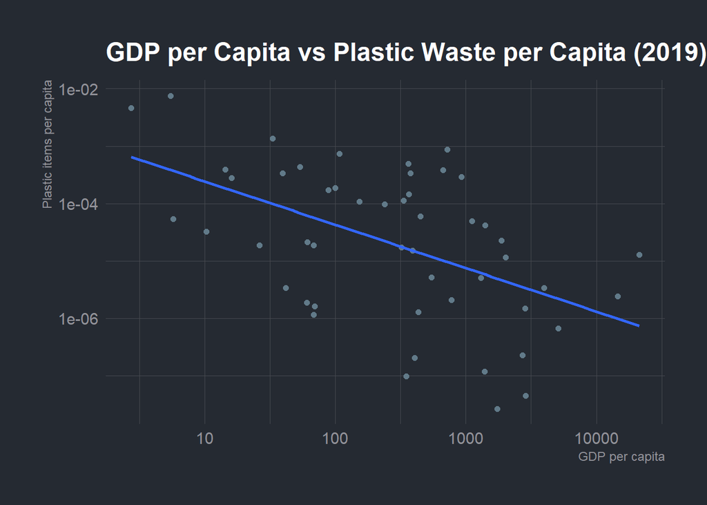

```r
graph1 <- meta_set %>%
  filter(year == 2019, parent_company == "Grand Total")

graph1 <- graph1 %>%
  mutate(
    gdp_per_capita = gdp_billions * 1,000,000,000 / population,
    plastic_waste_per_capita = grand_total / population
  )

ggplot(graph1, aes(x = gdp_per_capita, y = plastic_waste_per_capita)) +
  geom_point() +
  geom_smooth(method = "lm", se = FALSE) +
  labs(
    title = "GDP per Capita vs Plastic Waste per Capita (2019)",
    x = "GDP per capita",
    y = "Plastic items per capita"
  ) +
  scale_x_log10() +
  scale_y_log10() +
    theme_ft_rc()
```

```r
model_data <- meta_set %>%
  filter(year == 2019, parent_company == "Grand Total") %>%
  mutate(
    gdp_per_capita = gdp_billions * 1e9 / population,
    plastic_waste_per_capita = grand_total / population
  )

model <- lm(
  log10(plastic_waste_per_capita) ~ log10(gdp_per_capita),
  data = model_data
)

model_table <- summary(model)$coefficients %>%
  as.data.frame() %>%
  tibble::rownames_to_column("term") %>%
  mutate(
    term = recode(term,
      `(Intercept)` = "Intercept",
      `log10(gdp_per_capita)` = "GDP Per Capita"
    )
  )

model_table %>%
  gt() %>%
  cols_label(
    term = "Variable",
    Estimate = "Estimate",
    `Std. Error` = "Std. Error",
    `t value` = "t-value",
    `Pr(>|t|)` = "p-value"
  ) %>%
  fmt_number(
    columns = c(Estimate, `Std. Error`, `t value`, `Pr(>|t|)`),
    decimals = 4
  ) %>%
  tab_style(
    style = cell_text(weight = "bold"),
    locations = cells_column_labels()
  ) %>%
  tab_header(
    title = md("**Regression Results: GDP vs Plastic Waste**"),
    subtitle = md("Linear Model for 2019 Per Capita Data (log scaled)")
  ) %>%
  tab_caption(
    md("Table 3: Linear regression examining the relationship between GDP per capita and plastic waste per capita in 2019.")
  )
```

Table 3: Linear regression examining the relationship between GDP per capita and plastic waste per capita in 2019.

**Regression Results: GDP vs Plastic Waste**

Linear Model for 2019 Per Capita Data (log scaled)

| Variable | Estimate | Std. Error | t-value | p-value |
| --- | --- | --- | --- | --- |
| Intercept | −1.9542 | 1.2140 | −1.6097 | 0.1140 |
| GDP Per Capita | −0.6864 | 0.3011 | −2.2792 | 0.0271 |

The regression shows a negative relationship between GDP per capita and plastic waste per capita. This is suggested by the negative coefficient and implies that a increase in GDP means an decrease in plastic waste per capita. With a p-value of 0.02 on the slope we have sufficient evidence to conclude that there is a relationship between the two varaibles.

Percent change in CO2 Emission and Plastic Waste per capita from 2019-2020

```r
meta_set <- meta_set %>%
  mutate(
    parent_company = ifelse(
      parent_company %in% c("NULL", "null"),
      "Grand Total",
      parent_company
    )
  )


co2_change <- co2 %>%
  filter(year %in% c(2019, 2020),
         country == "World") %>%
  summarise(
    pct_change = (co2_per_capita[year == 2020] - co2_per_capita[year == 2019]) /
                 co2_per_capita[year == 2019] * 100
  )

plastic_data <- meta_set %>%
  filter(parent_company == "Grand Total") %>%
  group_by(year) %>%
  summarise(
    total_plastic = sum(grand_total),
    total_population = sum(population),
    per_capita = total_plastic / total_population
  )

plastic_change <- plastic_data %>%
  summarise(
    pct_change = (per_capita[year == 2020] - per_capita[year == 2019]) /
                 per_capita[year == 2019] * 100
  )

summary_table<- tibble(
  waste_metric = c("CO2 per capita", "Plastic per capita"),
  percentage_change = c(co2_change$pct_change,
                 plastic_change$pct_change)
)

summary_table %>%
  gt() %>%
  tab_header(
    title = md("**Change in CO2 Emission and Plastic Waste (2019-2020)**"),
    subtitle = md("Percent Change in Per Capita Values")
  ) %>%
  fmt_number(
    columns = percentage_change,
    decimals = 2
  ) %>%
  cols_label(
    waste_metric = "Waste",
    percentage_change = "Percent Change (%)"
  ) %>%
  tab_style(
    style = cell_text(weight = "bold"),
    locations = cells_column_labels()
  ) %>%
  tab_caption(
    md("Table 4: Shwoing the percent change in CO2 Emissions and Plastic Waste per
       capita for 2019 to 2020.")
  )
```

Table 4: Shwoing the percent change in CO2 Emissions and Plastic Waste per capita for 2019 to 2020.

**Change in CO2 Emission and Plastic Waste (2019-2020)**

Percent Change in Per Capita Values

| Waste | Percent Change (%) |
| --- | --- |
| CO2 per capita | −6.11 |
| Plastic per capita | −61.29 |

There was a clear and evident decrease in the amount of CO2 Emissions and Plastic Waste per capita from 2019-2020. However, Plastic waste per capita saw a much more significant decrease than CO2 Emissions, likely due to people not leaving their houses per the pandemic.

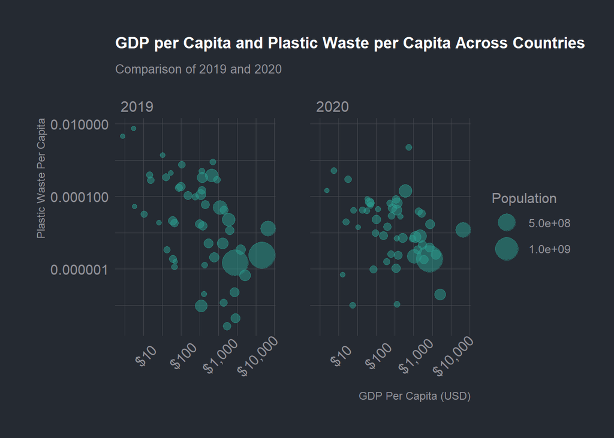

```r
graph2 <- meta_set %>%
  filter(parent_company == "Grand Total")

graph2 <- graph2 %>%
  mutate(
    gdp_per_capita = gdp_billions * 1,000,000,000 / population,
    plastic_waste_per_capita = grand_total / population
  )

ggplot(graph2,
       aes(
         x =gdp_per_capita,
         y = plastic_waste_per_capita,
         size = population)) +
  facet_wrap(.~year) +
  geom_point(alpha = 0.5, color = "#2A9D8F") +
  scale_size(range = c(1.5,10), name = "Population") +
  scale_x_log10(labels = scales::label_dollar()) +
  scale_y_log10(labels = scales::label_number()) +
  theme_ft_rc() +
  labs(
    x = "GDP Per Capita (USD)",
    y = "Plastic Waste Per Capita",
    title = "GDP per Capita and Plastic Waste per Capita Across Countries",
    subtitle = "Comparison of 2019 and 2020"
  ) +
  theme(
    plot.title = element_text(size = 13),
    plot.subtitle = element_text(size = 10),
    axis.text.x = element_text(angle = 45, vjust = .75)
  )
```

## 2.3 RQ 2 Data Summary (1 of 2):

Is there a visible trend between countries per capita numbers and population?

```r
country_gdp_co2_summary <- function(data) {

  data |>
    filter(
      year == 2019,
      !is.na(country.x),
      country.x != "Taiwan_ Republic of China (ROC)"
    ) |>
    group_by(country.x) |>
    summarise(
      gdp_per_capita = mean(gdp_billions * 1e9 / population, na.rm = TRUE),
      co2_per_capita = mean(co2_per_capita, na.rm = TRUE),
      population = mean(population, na.rm = TRUE),
      .groups = "drop"
    ) |>
    arrange(desc(population))
}

gdp_co2_table <- country_gdp_co2_summary(meta_set)

gdp_co2_table |>
  slice_head(n = 10) |>
  gt() |>
  cols_label(
    country.x = "Country",
    gdp_per_capita = "GDP Per Capita",
    co2_per_capita = "CO2 per Capita",
    population = "Population") |>
  fmt_number(
    columns = c(gdp_per_capita, co2_per_capita, population),
    decimals = 0,
    use_seps = TRUE
  ) |>
  tab_header(
    title = md("**GDP vs CO2 Emissions per Capita (2019)**"),
    subtitle = "Top 10 countries sorted by population"
  ) |>
  tab_caption(
    "Table 5: Countries GDP per capita & CO2 per capita, sorted by population"
  ) |>
  fmt_currency(
  columns = contains("gdp"),
  currency = "USD",
  decimals = 0
)
```

Table 5: Countries GDP per capita & CO2 per capita, sorted by population

**GDP vs CO2 Emissions per Capita (2019)**

Top 10 countries sorted by population

| Country | GDP Per Capita | CO2 per Capita | Population |
| --- | --- | --- | --- |
| China | $10,228 | 8 | 1,423,520,357 |
| India | $2,041 | 2 | 1,389,030,307 |
| United States of America | $63,297 | 16 | 337,790,069 |
| Indonesia | $4,107 | 2 | 272,489,381 |
| NIGERIA | $3,190 | 1 | 209,485,637 |
| Brazil | $9,030 | 2 | 207,455,459 |
| Bangladesh | $2,130 | 1 | 164,913,060 |
| Japan | $40,395 | 9 | 126,699,421 |
| Mexico | $10,370 | 4 | 125,762,978 |
| Philippines | $3,401 | 1 | 110,804,685 |

## 2.4 RQ 2 Data Summary (2 of 2):

Does there appear to be a relationship between the rank of a countries GDP per capita and their CO2 per capita?

```r
countries <- meta_set |>
  filter(
    year == 2019,
    !is.na(country.x),
    country.x != "Taiwan"
  ) |>
  distinct(country.x) |>
  pull(country.x)

ranked_table <- map_dfr(countries, function(c) {
  meta_set |>
    filter(country.x == c, year == 2019) |>
    summarise(
      country = c,
      gdp_per_capita = mean(gdp_billions * 1e9 / population, na.rm = TRUE),
      co2_per_capita = mean(co2_per_capita, na.rm = TRUE)
    )
}) |>
  filter(!is.na(gdp_per_capita), !is.na(co2_per_capita)) |>
  mutate(
    gdp_rank = min_rank(desc(gdp_per_capita)),
    co2_rank = min_rank(desc(co2_per_capita))
  ) |>
  arrange(gdp_rank)

ranked_table |>
  slice_head(n = 10) |>
  gt() |>
  cols_label(
    country = "Country",
    gdp_per_capita = "GDP Per Capita",
    co2_per_capita = "CO2 Per Capita",
    gdp_rank = "GDP Rank",
    co2_rank = "CO2 Rank"
  ) |>
  fmt_currency(
    columns = contains("gdp"),
    currency = "USD",
    decimals = 0
  ) |>
  fmt_number(
    columns = c(co2_per_capita),
    decimals = 2,
    use_seps = TRUE
  ) |>
  fmt_number(
    columns = c(gdp_rank, co2_rank),
    decimals = 0
  ) |>
  tab_spanner(
    label = "Per-Capita Measures",
    columns = c(gdp_per_capita, co2_per_capita)
  ) |>
  tab_spanner(
    label = "Global Rankings",
    columns = c(gdp_rank, co2_rank)
  ) |>
  data_color(
    columns = c(gdp_rank, co2_rank),
    fn = scales::col_numeric(
      palette = c("#DCEAF7", "#2C7FB8"),
      domain = c(1, 30)
    )
  ) |>
  tab_header(
    title = md("**GDP and CO2 Per-Capita Ranking Comparison**"),
    subtitle = "Top 10 countries ranked by GDP per capita in 2019"
  ) |>
  tab_caption(
    "Table 6: Comparison of country rankings for GDP per capita and CO2 emissions per capita in 2019."
  ) |>
  tab_style(
    style = cell_text(weight = "bold"),
    locations = cells_column_labels()
  )
```

Table 6: Comparison of country rankings for GDP per capita and CO2 emissions per capita in 2019.

**GDP and CO2 Per-Capita Ranking Comparison**

Top 10 countries ranked by GDP per capita in 2019

| Country | Per-Capita Measures GDP Per Capita | Per-Capita Measures CO2 Per Capita | Global Rankings GDP Rank | Global Rankings CO2 Rank |
| --- | --- | --- | --- | --- |
| Luxembourg | $112,666 | 15.72 | 1 | 3 |
| Switzerland | $84,100 | 4.29 | 2 | 24 |
| Ireland | $82,540 | 7.54 | 3 | 11 |
| United States of America | $63,297 | 15.50 | 4 | 4 |
| Australia | $54,874 | 16.28 | 5 | 2 |
| Netherlands | $52,967 | 8.71 | 6 | 6 |
| Hong Kong | $48,502 | 5.60 | 7 | 17 |
| Germany | $47,390 | 8.48 | 8 | 8 |
| United Arab Emirates | $46,271 | 21.76 | 9 | 1 |
| Canada | $46,151 | 15.32 | 10 | 5 |

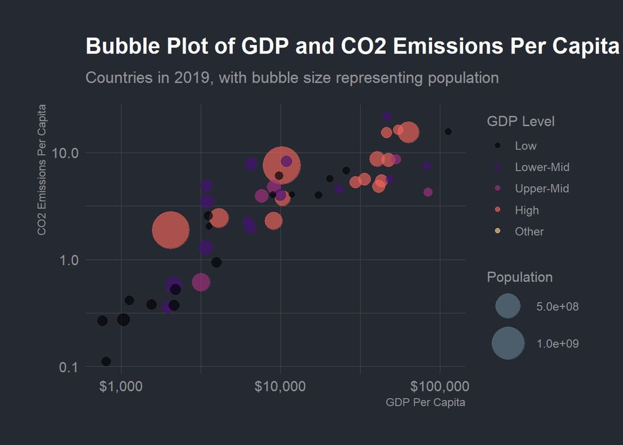

Figure 1: GDP per capita and CO2 emissions per capita across countries in 2019, with bubble size representing population.

```r
model_data %>%
  arrange(desc(population)) %>%
  mutate(
    country.x = as.factor(country.x),
    gdp_level = case_when(
      is.na(gdp_billions) ~ "Other",
      gdp_billions < 100 ~ "Low",
      gdp_billions < 500 ~ "Lower-Mid",
      gdp_billions < 1000 ~ "Upper-Mid",
      gdp_billions >= 1000 ~ "High"
    ),
    gdp_level = factor(
      gdp_level,
      levels = c("Low", "Lower-Mid", "Upper-Mid", "High", "Other")
    )
  ) %>%
  ggplot(aes(
    x = gdp_per_capita,
    y = co2_per_capita,
    size = population,
    color = gdp_level
  )) +
  geom_point(alpha = 0.65) +
  scale_size(range = c(2, 14), name = "Population") +
  scale_color_viridis_d(option = "A", end = 0.9, name = "GDP Level") +
  scale_x_log10(labels = scales::label_dollar()) +
  scale_y_log10(labels = scales::label_number()) +
  theme_ft_rc() +
  labs(
    x = "GDP Per Capita",
    y = "CO2 Emissions Per Capita",
    title = "Bubble Plot of GDP and CO2 Emissions Per Capita",
    subtitle = "Countries in 2019, with bubble size representing population"
  )
```

*Alt text:* Bubble plot of GDP per capita versus CO2 emissions per capita for 51 countries in 2019. Bubble size represents population and color indicates GDP level. Countries with higher GDP per capita tend to also have higher CO2 emissions per capita.

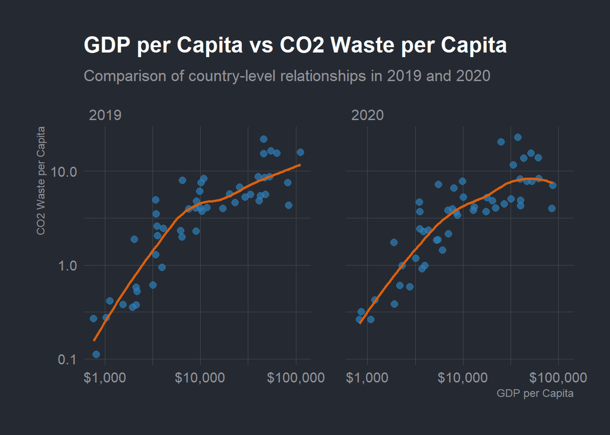

Figure 2: Relationship between GDP per capita and CO2 waste per capita across countries in 2019 and 2020, with separate panels for each year.

```r
ggplot(
  meta_set %>%
    filter(year %in% c(2019, 2020), parent_company == "Grand Total"),
  aes(x = gdp_per_capita, y = co2_per_capita)
) +
  geom_point(color = "#2C7FB8", alpha = 0.7, size = 2.5) +
  geom_smooth(method = "loess", se = FALSE, color = "#D95F0E", linewidth = 1) +
  scale_x_log10(labels = scales::label_dollar()) +
  scale_y_log10(labels = scales::label_number()) +
  facet_wrap(~year) +
  labs(
    title = "GDP per Capita vs CO2 Waste per Capita",
    subtitle = "Comparison of country-level relationships in 2019 and 2020",
    x = "GDP per Capita",
    y = "CO2 Waste per Capita"
  ) +
  theme_ft_rc()
```

*Alt text:* Faceted scatterplot showing GDP per capita versus CO2 waste per capita for countries in 2019 and 2020. Each panel includes a fitted trend line. The relationship appears positive in both years, allowing comparison of how the pattern changes between 2019 and 2020.